# Machine Learning Class Project

Brian Ostrovsky

March 8, 2015

## Background (directly from the assignment)

Using devices such as Jawbone Up, Nike FuelBand, and Fitbit it is now possible to collect a large amount of data about personal activity relatively inexpensively. These type of devices are part of the quantified self movement – a group of enthusiasts who take measurements about themselves regularly to improve their health, to find patterns in their behavior, or because they are tech geeks. One thing that people regularly do is quantify how much of a particular activity they do, but they rarely quantify how well they do it. In this project, your goal will be to use data from accelerometers on the belt, forearm, arm, and dumbell of 6 participants. They were asked to perform barbell lifts correctly and incorrectly in 5 different ways. More information is available from the website here: http://groupware.les.inf.puc-rio.br/har (see the section on the Weight Lifting Exercise Dataset).

## Data (directly from the assignment)

The training data for this project are available here: https://d396qusza40orc.cloudfront.net/predmachlearn/pml-training.csv

The test data are available here: https://d396qusza40orc.cloudfront.net/predmachlearn/pml-testing.csv

The data for this project come from this source: http://groupware.les.inf.puc-rio.br/har. If you use the document you create for this class for any purpose please cite them as they have been very generous in allowing their data to be used for this kind of assignment.

Six young health participants were asked to perform one set of 10 repetitions of the Unilateral Dumbbell Biceps Curl in five different fashions: exactly according to the specification (Class A), throwing the elbows to the front (Class B), lifting the dumbbell only halfway (Class C), lowering the dumbbell only halfway (Class D) and throwing the hips to the front (Class E)

Read more: http://groupware.les.inf.puc-rio.br/har#ixzz3Ts5IP9sp

## Assignment

The objective of the assignment is to predict the manner in which the exercise was performed using the “classe” variable (explained in the preceeding section as Class A through Class E) in the training dataset. This report will describe how the model was built, cross-validation methods used and the expected out of sample error as well as why the choices were made. Finally, we will apply the model to a test dataset of 20 cases which will be submitted for grading.

## Load Data and Variable Cleanup

Here we load the data downloaded from the source mentioned above. We set NA’a to 0 in aniticpation of eliminating near zero variables. We then isolated and removed near-zero variables reducing the number of variables from 160 down to 52. We then split the training setup (60%/40%) into a train and test data set and renamed the orignal pml.testing set validationset.

```r
nzv <- nearZeroVar(trainingset)
filteredTrain <- trainingset[, -nzv]
filteredTrain <- filteredTrain[, -c(1:7)]

inTrain <- createDataPartition(y=filteredTrain$classe, p=0.6, list=FALSE)
train <- filteredTrain[inTrain,]
test <- filteredTrain[-inTrain,]

####Complete Fileters Test Set (seperated into test and train)
dim(filteredTrain)
```

```
## [1] 19622    52
```

```r
#### final processed train dataset
dim(train)
```

```
## [1] 11776    52
```

```r
####final processed test dataset
dim(test)
```

```
## [1] 7846   52
```

We now remove the near-zero and non-classifying columns (columns 1-7) from the validation data set. The final validation data set to be used for submission is filteredVal and has 52 variables.

```r
nzv1 <- nearZeroVar(validationset)
filteredVal <- validationset[, -nzv1]
filteredVal <- filteredVal[, -c(1:7)]
####final processed validation dataset to used for submission
dim(filteredVal)
```

```
## [1] 20 52
```

## Model Selection and Testing

We chose to test both the Decision Tree and Random Forrest models (shown below) as they are strong classification engines.

### Decision Tree Model

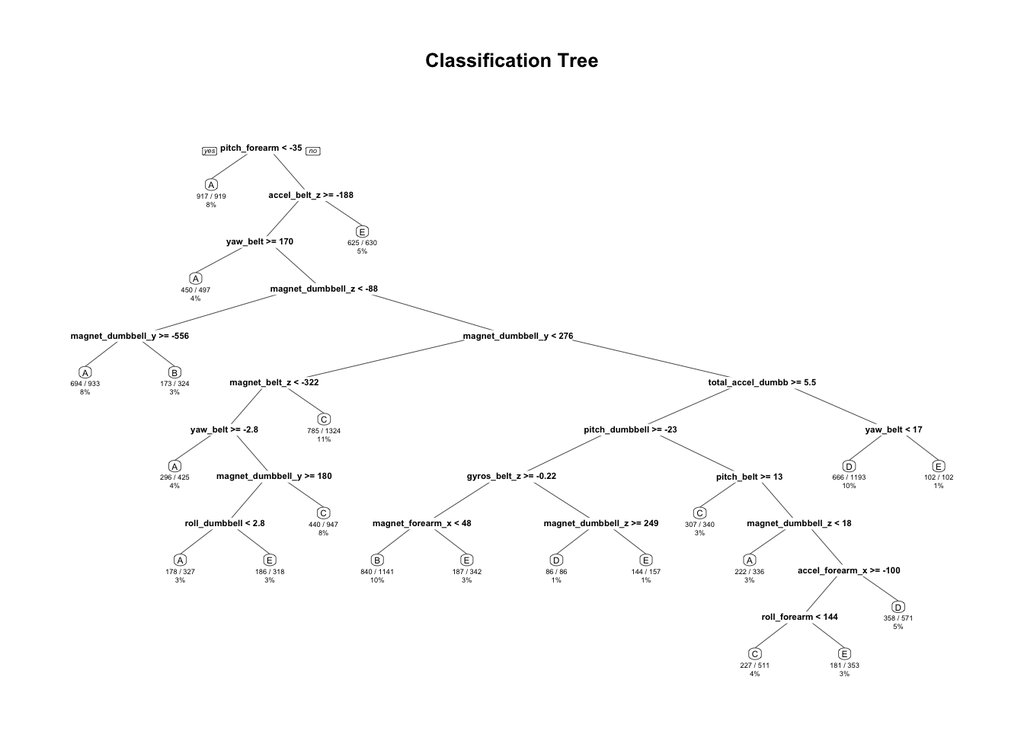

```r
modelFitClass <- rpart(classe ~ ., data=train, method="class")
predictionClass <- predict(modelFitClass, test, type = "class")
rpart.plot(modelFitClass, main="Classification Tree", extra=102, under=TRUE, faclen=0)
```

```r
confusionMatrix(predictionClass, test$classe)
```

```
## Confusion Matrix and Statistics
##
##           Reference
## Prediction    A    B    C    D    E
##          A 1858  235   38   29  168
##          B   21  685   54  131  107
##          C  115  315 1149  380  152
##          D  222  118   43  692  118
##          E   16  165   84   54  897
##
## Overall Statistics
##
##                Accuracy : 0.6731
##                  95% CI : (0.6626, 0.6835)
##     No Information Rate : 0.2845
##     P-Value [Acc > NIR] : < 2.2e-16
##
##                   Kappa : 0.5865
##  Mcnemar's Test P-Value : < 2.2e-16
##
## Statistics by Class:
##
##                      Class: A Class: B Class: C Class: D Class: E
## Sensitivity            0.8324  0.45125   0.8399   0.5381   0.6221
## Specificity            0.9163  0.95054   0.8515   0.9236   0.9502
## Pos Pred Value         0.7981  0.68637   0.5443   0.5801   0.7377
## Neg Pred Value         0.9322  0.87836   0.9618   0.9107   0.9178
## Prevalence             0.2845  0.19347   0.1744   0.1639   0.1838
## Detection Rate         0.2368  0.08731   0.1464   0.0882   0.1143
## Detection Prevalence   0.2967  0.12720   0.2691   0.1521   0.1550
## Balanced Accuracy      0.8744  0.70089   0.8457   0.7309   0.7861
```

As we see, this yields a model that is roughly 67% predictive.

### Random Forest Model

The Random Trees algorighm was run with 4 fold cross validation.

```r
set.seed(1234)
modFit2 <- train(classe~.,data=train,method="rf",trControl=trainControl(method="cv",number=4),prox=TRUE, allowParallel=TRUE)
modFit2
```

```
## Random Forest
##
## 11776 samples
##    51 predictor
##     5 classes: 'A', 'B', 'C', 'D', 'E'
##
## No pre-processing
## Resampling: Cross-Validated (4 fold)
##
## Summary of sample sizes: 8832, 8833, 8832, 8831
##
## Resampling results across tuning parameters:
##
##   mtry  Accuracy   Kappa      Accuracy SD  Kappa SD
##    2    0.9869226  0.9834534  0.001764014  0.002234221
##   26    0.9893851  0.9865702  0.001123917  0.001421842
##   51    0.9828465  0.9782988  0.004210434  0.005327402
##
## Accuracy was used to select the optimal model using  the largest value.
## The final value used for the model was mtry = 26.
```

```r
predictions2 <- predict(modFit2, newdata=test)
print(confusionMatrix(predictions2, test$classe), digits=4)
```

```
## Confusion Matrix and Statistics
##
##           Reference
## Prediction    A    B    C    D    E
##          A 2232   20    0    0    0
##          B    0 1493   14    0    2
##          C    0    5 1347   15    2
##          D    0    0    7 1269    3
##          E    0    0    0    2 1435
##
## Overall Statistics
##
##                Accuracy : 0.9911
##                  95% CI : (0.9887, 0.993)
##     No Information Rate : 0.2845
##     P-Value [Acc > NIR] : < 2.2e-16
##
##                   Kappa : 0.9887
##  Mcnemar's Test P-Value : NA
##
## Statistics by Class:
##
##                      Class: A Class: B Class: C Class: D Class: E
## Sensitivity            1.0000   0.9835   0.9846   0.9868   0.9951
## Specificity            0.9964   0.9975   0.9966   0.9985   0.9997
## Pos Pred Value         0.9911   0.9894   0.9839   0.9922   0.9986
## Neg Pred Value         1.0000   0.9961   0.9968   0.9974   0.9989
## Prevalence             0.2845   0.1935   0.1744   0.1639   0.1838
## Detection Rate         0.2845   0.1903   0.1717   0.1617   0.1829
## Detection Prevalence   0.2870   0.1923   0.1745   0.1630   0.1832
## Balanced Accuracy      0.9982   0.9905   0.9906   0.9926   0.9974
```

#### The out of sample error on this model is .0089 ( 1 minus the model accuracy, 1-.9911).

## Prediction Assignment Submission

```r
answers <- predict(modFit2, newdata=filteredVal)
answers
```

```
##  [1] B A B A A E D B A A B C B A E E A B B B
## Levels: A B C D E
```

```r
pml_write_files = function(x){
  n = length(x)
  for(i in 1:n){
    filename = paste0("problem_id_",i,".txt")
    write.table(x[i],file=filename,quote=FALSE,row.names=FALSE,col.names=FALSE)
  }
}

pml_write_files(answers)
```

Predictions submitted and 20 of 20 are correct.

## Conclusions and Observtions

The random forest appraoch with cross validation proved to be extremely accurate and help up in the submitted assignment.